# Homework 9: Using real-world data for hypothesis generation

Sydney Ng UNI: sn2863

Due: Tuesday, March 23, 2021 at 5:30 PM

# Examining the features

### Load .Rdata file and merge into single data frame

```r
library(tidyverse)
library(caret)
library(rpart.plot)

#Load data using path of where file is stored
load("./exposome.RData")

#Merge all data frames into a single data frame. FYI, this is just a shortcut by combining baseR with piping from tidyverse. There are other ways of merging across three data frames that are likely more elegant. Reminder: Merging into a single data frame is optional. Depends upon how you program. This example will assume you've merged everything into a single data frame.

studydata<-merge(exposome,phenotype,by="ID") %>% merge(covariates, by="ID") %>%
  mutate(hs_asthma = as.factor(hs_asthma))

#Strip off ID Variable
studydata$ID<-NULL
```

### Looking at demographics and maternal information during pregnancy.

```r
summary(covariates)
```

```
##        ID       h_cohort e3_sex_None  e3_yearbir_None  h_mbmi_None
##  Min.   :   1   1:202    female:608   2003: 55        Min.   :15.88
##  1st Qu.: 326   2:198    male  :693   2004:107        1st Qu.:21.26
##  Median : 651   3:224                 2005:241        Median :24.02
##  Mean   : 651   4:207                 2006:256        Mean   :25.03
##  3rd Qu.: 976   5:272                 2007:250        3rd Qu.:27.34
##  Max.   :1301   6:198                 2008:379        Max.   :51.42
##                                       2009: 13
##  hs_wgtgain_None  e3_gac_None      h_age_None    h_edumc_None h_native_None
##  Min.   : 0.0    Min.   :28.00   Min.   :16.00   1:178        0: 146
##  1st Qu.: 9.0    1st Qu.:38.71   1st Qu.:27.64   2:449        1:  67
##  Median :12.0    Median :40.00   Median :31.00   3:674        2:1088
##  Mean   :13.5    Mean   :39.63   Mean   :30.80
##  3rd Qu.:18.0    3rd Qu.:40.71   3rd Qu.:34.06
##  Max.   :55.0    Max.   :44.14   Max.   :43.51
##
##  h_parity_None hs_child_age_None hs_c_height_None hs_c_weight_None
##  0:601         Min.   : 5.437    Min.   :1.054    Min.   :16.00
##  1:464         1st Qu.: 6.500    1st Qu.:1.209    1st Qu.:22.90
##  2:236         Median : 8.033    Median :1.280    Median :26.90
##                Mean   : 7.976    Mean   :1.291    Mean   :28.52
##                3rd Qu.: 8.920    3rd Qu.:1.365    3rd Qu.:32.70
##                Max.   :12.101    Max.   :1.685    Max.   :71.10
##
```

- There are no missing values in the `covariates` dataset containing demographic and maternal information during the mother’s pregnancy. We also see that there are 1301 mothers in this dataset.
- `h_parity_None`: Looking further at the mother’s information, 46.2% of the women were nulliparous, meaning they have never given birth before, 35.66% have given birth once before, and 18.14% have given birth at least twice before their current pregnancy.
- `h_edumc_None`: Looking further at the education of the mothers, 13.68% have a primary school education, 34.51% have a secondary school education, and 51.81% have a university degree or higher.

### Looking at health outcomes measured during the study.

```r
phenotype <-
  phenotype %>%
  mutate(hs_asthma = as.factor(hs_asthma))
summary(phenotype)
```

```
##        ID           e3_bw      hs_asthma  hs_zbmi_who      hs_correct_raven
##  Min.   :   1   Min.   :1100   0:1159    Min.   :-3.5800   Min.   : 9.00
##  1st Qu.: 326   1st Qu.:3080   1: 142    1st Qu.:-0.4000   1st Qu.:22.00
##  Median : 651   Median :3398             Median : 0.2800   Median :27.00
##  Mean   : 651   Mean   :3389             Mean   : 0.4032   Mean   :26.29
##  3rd Qu.: 976   3rd Qu.:3720             3rd Qu.: 1.1300   3rd Qu.:32.00
##  Max.   :1301   Max.   :5260             Max.   : 4.7200   Max.   :36.00
##    hs_Gen_Tot     hs_bmi_c_cat
##  Min.   :  0.00   1: 13
##  1st Qu.: 10.00   2:904
##  Median : 20.00   3:253
##  Mean   : 24.38   4:131
##  3rd Qu.: 33.44
##  Max.   :133.00
```

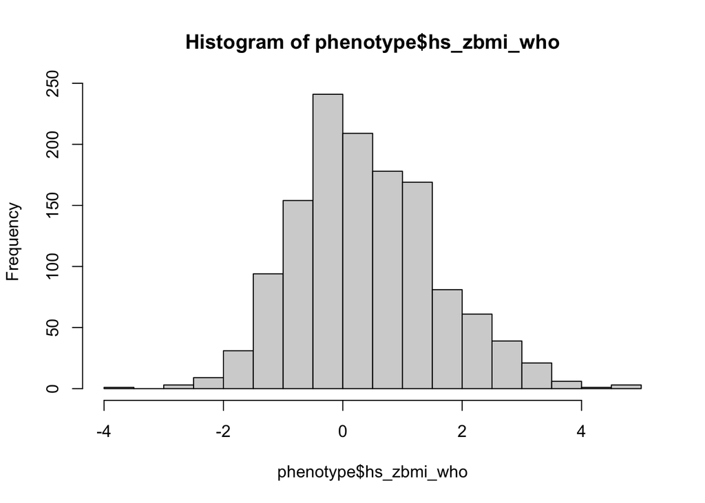

```r
hist(phenotype$hs_zbmi_who)
```

- `hs_asthma`: 89.09% of children in the study have never had asthma 10.91% of children do. There is a big imbalance in asthma diagnosis. This could be a potential outcome to focus in on!
- `hs_zbmi_who`: Looking at the standardized BMI variable, we see that it does not deviate too far from a normal distribution, though can be slightly right skewed because there may be more obese children in the dataset.
- `hs_Gen_Tot`: Neuro behavior defined as internalizing and externalizing problems at 6-11 years old on the CBCL scale has a min of 0.00 and max of 133.00 and a median of 20.00. This also indicates that there is a heavy right skew in the distribution.

### Looking at the environmental features measured on children.

```r
exposome %>% select(contains("pcb"), hs_pet_cat_r2_None, hs_pet_dog_r2_None) %>% summary()
```

```
##  hs_pcb118_cadj_Log2 hs_pcb118_madj_Log2 hs_pcb138_cadj_Log2
##  Min.   :-6.9507     Min.   :-1.170      Min.   :-9.432
##  1st Qu.: 0.6038     1st Qu.: 0.627      1st Qu.: 1.744
##  Median : 1.0007     Median : 1.052      Median : 2.416
##  Mean   : 1.1023     Mean   : 1.250      Mean   : 2.402
##  3rd Qu.: 1.5596     3rd Qu.: 1.829      3rd Qu.: 3.110
##  Max.   : 4.7829     Max.   : 7.426      Max.   : 7.746
##  hs_pcb138_madj_Log2 hs_pcb153_cadj_Log2 hs_pcb153_madj_Log2
##  Min.   :-10.187     Min.   :1.207       Min.   :1.110
##  1st Qu.:  1.788     1st Qu.:2.858       1st Qu.:2.852
##  Median :  2.921     Median :3.519       Median :3.854
##  Mean   :  2.868     Mean   :3.555       Mean   :3.892
##  3rd Qu.:  3.794     3rd Qu.:4.218       3rd Qu.:4.739
##  Max.   :  8.206     Max.   :7.764       Max.   :9.839
##  hs_pcb170_cadj_Log2 hs_pcb170_madj_Log2 hs_pcb180_cadj_Log2
##  Min.   :-16.8417    Min.   :-2.0418     Min.   :-11.7198
##  1st Qu.: -0.8488    1st Qu.:-0.3211     1st Qu.:  0.6983
##  Median :  0.2765    Median : 0.8727     Median :  1.8340
##  Mean   : -0.3076    Mean   : 1.0875     Mean   :  1.7477
##  3rd Qu.:  1.3909    3rd Qu.: 2.2000     3rd Qu.:  3.0077
##  Max.   :  4.7832    Max.   : 7.7831     Max.   :  5.8781
##  hs_pcb180_madj_Log2 hs_sumPCBs5_cadj_Log2 hs_sumPCBs5_madj_Log2
##  Min.   :-10.121     Min.   :2.182         Min.   :2.299
##  1st Qu.:  2.069     1st Qu.:3.857         1st Qu.:4.007
##  Median :  2.990     Median :4.612         Median :4.715
##  Mean   :  2.946     Mean   :4.647         Mean   :4.860
##  3rd Qu.:  4.034     3rd Qu.:5.372         3rd Qu.:5.738
##  Max.   :  9.349     Max.   :9.277         Max.   :9.341
##  hs_pet_cat_r2_None hs_pet_dog_r2_None
##  0:1059             0:1108
##  1: 242             1: 193
##
##
##
##
```

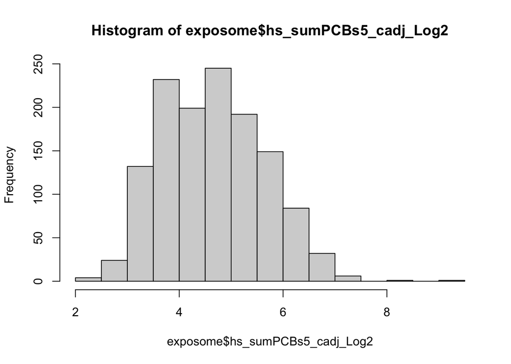

```r
hist(exposome$hs_sumPCBs5_cadj_Log2)
```

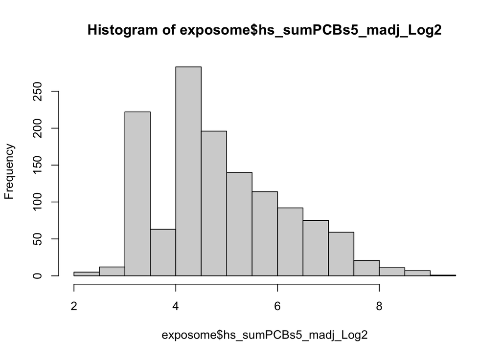

```r
hist(exposome$hs_sumPCBs5_madj_Log2)
```

# Developing a Research Question

**Outcome:** `hs_asthma` a binary variable, whether or not the child was ever diagnosed with asthma by a doctor

**Research Question:** What features from the exposome HELIX dataset can predict child asthma diagnosis?

# Implementing a Pipeline and Algorithm

### Looking at missingness and correlated variables, scaling and centering

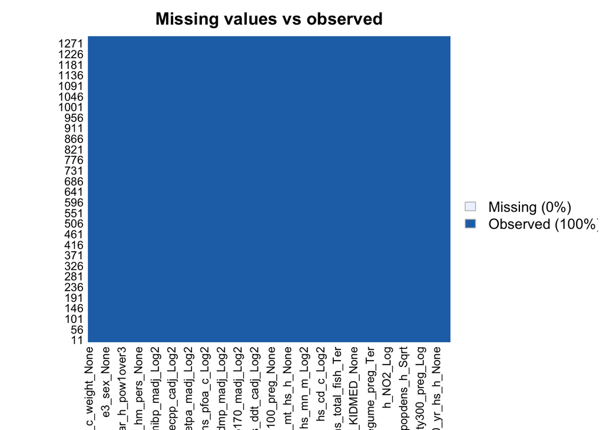

```r
library(Amelia)
missmap(studydata, main = "Missing values vs observed")
```

```r
# Correlations
dat_num <- studydata %>% select(where(is.numeric))
dat_not_num <- studydata %>% select(!where(is.numeric))

correlations <- cor(dat_num, use="complete.obs")
high_correlations <- findCorrelation(correlations, cutoff=0.4)

dat_num <- dat_num[-high_correlations] # getting rid of highly correlated columns

# Centering and Scaling
set.up.preprocess <- preProcess(dat_num, method = c("center", "scale"))
# Output pre-processed values
transformed_vals <- predict(set.up.preprocess, dat_num)
dat_transformed <- bind_cols(transformed_vals, dat_not_num)

# Checking the new dimensions of our dataset
dim(dat_transformed)
```

```
## [1] 1301  146
```

- After removing the highly correlated variables from our dataset, we have 146 variables remaining to work with.
- Because of the high number of features, I will perform an elastic net (regularized) logistic regression for classification. Not only can this potentially reduce our feature space further, but it would also be of interest to look at which features are most important and have clinical significance in predicting asthma diagnosis in children. Interpretation could be useful and important.

### Partitioning the data

```r
# Partitioning data
set.seed(100)
train.indices<-createDataPartition(y=studydata$hs_asthma,p=0.7,list=FALSE)
training <-studydata[train.indices, ]
testing <-studydata[-train.indices, ]

# Checking distribution of the outcome
training %>% group_by(hs_asthma) %>%
  summarise(count = n(), proportion = count/nrow(training))
```

```
## # A tibble: 2 x 3
##   hs_asthma count proportion
##   <fct>     <int>      <dbl>
## 1 0           812      0.890
## 2 1           100      0.110
```

```r
testing %>% group_by(hs_asthma) %>%
  summarise(count = n(), proportion = count/nrow(testing))
```

```
## # A tibble: 2 x 3
##   hs_asthma count proportion
##   <fct>     <int>      <dbl>
## 1 0           347      0.892
## 2 1            42      0.108
```

### Regularized (elastic net) logistic regression

```r
set.seed(100)
lambda <- 10^seq(-3,3, length=100)
alpha <- seq(0.001,1, length=20)
train_control <- trainControl(method="cv", number = 10, sampling = "down")
logistic_reg <- train(hs_asthma ~., data = training,
                      method = "glmnet", family = "binomial",
                      trControl = train_control, tuneLength=10,
                      tuneGrid=expand.grid(alpha=alpha, lambda=lambda))
logistic_reg$bestTune
```

```
##         alpha     lambda
## 632 0.3164737 0.07564633
```

- Down-sampling is used to address the outcome imbalance in our data. After performing a logistic regression with elastic net regularization, it turns out that the best tuning parameters for alpha and lambda are 0.3164737 and 0.0756463, respectively.

### Elastic net logistic regression results and predictions on training data

```r
# Coefficients for the regularized logistic regression
coef(logistic_reg$finalModel, logistic_reg$bestTune$lambda)
```

```
## 297 x 1 sparse Matrix of class "dgCMatrix"
##                                                               1
## (Intercept)                                       -2.045008e+00
## h_abs_ratio_preg_Log                              -1.877787e-01
## h_no2_ratio_preg_Log                               .
## h_pm10_ratio_preg_None                            -3.217897e-03
## h_pm25_ratio_preg_None                             .
## hs_no2_dy_hs_h_Log                                 .
## hs_no2_wk_hs_h_Log                                 .
## hs_no2_yr_hs_h_Log                                 .
## hs_pm10_dy_hs_h_None                              -1.092539e-02
## hs_pm10_wk_hs_h_None                               .
## hs_pm10_yr_hs_h_None                               .
## hs_pm25_dy_hs_h_None                              -1.398797e-02
## hs_pm25_wk_hs_h_None                               .
## hs_pm25_yr_hs_h_None                               .
## hs_pm25abs_dy_hs_h_Log                             .
## hs_pm25abs_wk_hs_h_Log                            -2.591140e-01
## hs_pm25abs_yr_hs_h_Log                             .
## h_accesslines300_preg_dic0                        -1.979948e-01
## h_accesspoints300_preg_Log                         1.349142e-02
## h_builtdens300_preg_Sqrt                          -4.858402e-05
## h_connind300_preg_Sqrt                             .
## h_fdensity300_preg_Log                             .
## h_frichness300_preg_None                           .
## h_landuseshan300_preg_None                         .
## h_popdens_preg_Sqrt                                .
## h_walkability_mean_preg_None                       .
## hs_accesslines300_h_dic0                           .
## hs_accesspoints300_h_Log                          -1.297569e-02
## hs_builtdens300_h_Sqrt                             .
## hs_connind300_h_Log                                .
## hs_fdensity300_h_Log                               .
## hs_landuseshan300_h_None                           8.101027e-01
## hs_popdens_h_Sqrt                                  .
## hs_walkability_mean_h_None                         .
## hs_accesslines300_s_dic0                           .
## hs_accesspoints300_s_Log                           .
## hs_builtdens300_s_Sqrt                             .
## hs_connind300_s_Log                                .
```

[output cut: 244 more lines]

```
## e3_yearbir_None2008                                .
## e3_yearbir_None2009                                3.694354e-01
## h_mbmi_None                                        .
## hs_wgtgain_None                                    .
## e3_gac_None                                        .
## h_age_None                                         .
## h_edumc_None2                                      .
## h_edumc_None3                                      .
## h_native_None1                                     4.266332e-01
## h_native_None2                                     .
## h_parity_None1                                     2.195086e-02
## h_parity_None2                                     .
## hs_child_age_None                                  .
## hs_c_height_None                                   .
## hs_c_weight_None                                   .
```

```r
# Making predictions
logistic_pred <- logistic_reg %>% predict(training)

# Confusion Matrix
confusion_logistic <-
  confusionMatrix(logistic_pred, training$hs_asthma,
                  positive = "1")
confusion_logistic$table
```

```
##           Reference
## Prediction   0   1
##          0 471  13
##          1 341  87
```

### Elastic net logistic regression results and predictions on testing data.

```r
# Making predictions
pred_asthma_test <- predict(logistic_reg, testing)
pred_asthma_prob_test <- predict(logistic_reg, testing, type="prob")

# Printing the confusion matrix
results_test <- confusionMatrix(pred_asthma_test, testing$hs_asthma, positive = "1")
print(results_test)
```

```
## Confusion Matrix and Statistics
##
##           Reference
## Prediction   0   1
##          0 176  14
##          1 171  28
##
##                Accuracy : 0.5244
##                  95% CI : (0.4735, 0.575)
##     No Information Rate : 0.892
##     P-Value [Acc > NIR] : 1
##
##                   Kappa : 0.0658
##
##  Mcnemar's Test P-Value : <2e-16
##
##             Sensitivity : 0.66667
##             Specificity : 0.50720
##          Pos Pred Value : 0.14070
##          Neg Pred Value : 0.92632
##              Prevalence : 0.10797
##          Detection Rate : 0.07198
##    Detection Prevalence : 0.51157
##       Balanced Accuracy : 0.58694
##
##        'Positive' Class : 1
##
```